# Progress Memo 1

Final Project  
Data Science 2 with R (STAT 301-2)

Author

Celena Kim

Published

February 4, 2024

**Github Repo Link**

[Celena Kim Repo Link](https://github.com/stat301-2-2024-winter/final-project-2-celenakim)

## Data source & Why this Data

The data that I chose for my project was derived from gathering data on the psychological analysis of comments under the Jubilee video titled [Are We Allies? Black Americans vs Asian Americans | Middle Ground](https://www.youtube.com/watch?v=pXo2ub_nZFc) found on [YouTube](https://www.youtube.com). This video features a poignant discussion between East Asian Americans and Black Americans, highlighting the conflict and tension present between these groups. As I am a part of the Social Cognition and Intergroup Processes Lab on campus, I thought it would be really interesting to combine social psych with data science to explore topics on bias and race through quantitative analysis. Therefore, I decided to explore the comments under this video through this project.

Using Python code, I first extracted each comment and its details such as like count and number of replies and put them into a spreadsheet. Then, utilizing the software LIWC[^1], a text analysis program that can categorize text by the overall emotion they convey, each comment was analyzed and given a score of how much they communicate each of 49 various emotions/categories such as anger, clout, affiliation, power, assent, insight, sad, etc.

<sup>1</sup> an explanation of how this software works can be found [here](https://www.liwc.app/help/howitworks)

## Data quality & complexity check

```r
library(tidyverse)
allies_data <- read_csv(here::here("data/raw/allies_video_data.csv"))
```

## Potential data issues

The biggest issue I see with my data is that the variable names regarding the basic details of the comments (“replies”, “like_count”, etc.) did not get copied over from the first spreadsheet and were thus replaced with letters A-P, so I will have to go back in and add those variable names once I clean this data set. Additionally, I may have to rename some of the emotion categories, as they may not be clear based on how they are named by LIWC.

## Prediction Problem

My predictive research question is: What factors lead to a comment receiving more likes on the Jubilee video, “Are We Allies? Black Americans vs Asian Americans | Middle Ground”?

This is a regression problem as I would like to predict a numerical outcome- the number of likes on a comment- and the target variable is the like count of a comment (variable `H` which will later be renamed to `like_count`). The predictors will be the emotional categories from LIWC. I also plan to create a categorical variable called “comment_length” that categories a comment based on a length of “one word”, “short” (1-3 sentences), or “long” (4+ sentences) to be used as a predictor.

This prediction model would be useful in determining what types of comments under the video are more likely to garner more attention/popularity. I think it would be very interesting to see overall the psychological implications of a comment’s emotional makeup and its engagement, especially regarding a video that is so touching.

## Target variable analysis

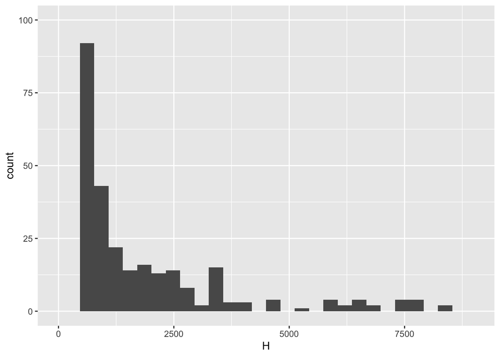

```r
allies_data |>
  ggplot(aes(x = H)) +
  geom_histogram() +
  xlim(0, 9000) +
  ylim(0, 100)
```

```r
skimr::skim(allies_data$H)
```

Data summary

| Name | allies_data$H |
| --- | --- |
| Number of rows | 15397 |
| Number of columns | 1 |
| _______________________ |  |
| Column type frequency: |  |
| numeric | 1 |
| ________________________ |  |
| Group variables | None |

**Variable type: numeric**

| skim_variable | n_missing | complete_rate | mean | sd | p0 | p25 | p50 | p75 | p100 | hist |
| --- | --- | --- | --- | --- | --- | --- | --- | --- | --- | --- |
| data | 0 | 1 | 58.78 | 693.31 | 0 | 0 | 1 | 3 | 38060 | ▇▁▁▁▁ |

The target variable, `H` (which will later be renamed to `like_count`) is a numerical type variable. A univariate analysis reveals that the distribution is skewed right, showing that a majority of comments usually get a lower number of likes. This means that a transformation may be necessary through means of log or square root transformation. A skim of the H variable shows that there does not appear to be any missing values.

## Misc

My next plan is to clean my data set by making the necessary variable name changes, and adding more categorical variables such as comment length categories. Since the LIWC variables are all numerical, I think it would be good to mutate more categorical variables.